# Trading and investment account summary

# For 2020-08-31

Summary text: The equity value of my live trading portfolio changed by 1.15 % (US$ 408.37 ) from US$ 35653.33 to US$ 36061.7 today ( 2020-08-31 ). The trading proceeds in my live account were US$ 96.3000000000002 . The book proceeds in my portfolio changed from US$ 2369.58 to US$ 2681.65

## Portfolio

The below table shows the current positions in the live account as well as their current and total performance. “book_proceed” indicates the unrealized profit in that position.

| symbol | close | closePerc | Total_Change_close | entry_price | position | position_size | entry_position | totalPerc | book_proceed | sector |
| --- | --- | --- | --- | --- | --- | --- | --- | --- | --- | --- |
| KWEB | 70.32 | -2.07 | -149 | 71.03 | 100 | 7032.00 | 7102.73 | -1.01 | -70.73 | Miscellaneous |
| BRK.B | 218.04 | -0.23 | -12.75 | 195.40 | 25 | 5451.00 | 4885.08 | 10.38 | 565.92 | Finance |
| SEAS | 20.39 | -4.54 | 174.6 | 19.05 | -180 | -3670.20 | -3429.01 | -6.57 | -241.19 | Consumer Services |
| CAKE | 29.51 | -4.16 | -128 | 24.53 | 100 | 2951.00 | 2452.55 | 16.89 | 498.45 | Consumer Services |
| TSLA | 2492.55 | 12.61 | 279.03 | 1405.56 | 1 | 2492.55 | 1405.56 | 43.61 | 1086.99 | Consumer Durables |
| SQ | 159.47 | 2.32 | 54.3 | 143.24 | 15 | 2392.05 | 2148.55 | 10.18 | 243.5 | Technology Services |
| EZA | 37.18 | -4.27 | 91.3 | 38.54 | -55 | -2044.90 | -2119.70 | 3.66 | 74.8 | Miscellaneous |
| INDA | 33.33 | -3.53 | -73.2 | 33.10 | 60 | 1999.80 | 1985.99 | 0.69 | 13.81 | Miscellaneous |
| GOOG | 1632.03 | -0.75 | -12.37 | 1599.21 | 1 | 1632.03 | 1599.21 | 2.01 | 32.82 | Technology Services |
| SLV | 26.23 | 2.49 | 31.85 | 22.90 | 50 | 1311.50 | 1144.95 | 12.7 | 166.55 | Miscellaneous |
| TPR | 14.73 | -1.01 | -12.75 | 14.96 | 85 | 1252.05 | 1271.99 | -1.59 | -19.94 | Retail Trade |
| MIK | 11.23 | 0.9 | 10 | 8.51 | 100 | 1123.00 | 851.26 | 24.2 | 271.74 | Retail Trade |
| MGM | 22.50 | -5.74 | -61.65 | 21.88 | 45 | 1012.50 | 984.75 | 2.74 | 27.75 | Consumer Services |
| IAU | 18.79 | 0.28 | 2.66 | 18.96 | 50 | 939.25 | 947.84 | -0.91 | -8.59 | Miscellaneous |
| UNM | 18.46 | -2.89 | -27.5 | 19.21 | 50 | 923.00 | 960.30 | -4.04 | -37.3 | Finance |
| ABT | 109.44 | -1.17 | -9.1 | 110.56 | 7 | 766.08 | 773.90 | -1.02 | -7.82 | Health Technology |
| RVLV | 20.08 | -0.15 | -1.14 | 18.07 | 38 | 763.04 | 686.53 | 10.03 | 76.51 | Retail Trade |
| GOLD | 29.64 | 1.51 | 11 | 28.06 | 25 | 741.00 | 701.56 | 5.32 | 39.44 | Non-Energy Minerals |
| SWKS | 144.84 | 0.85 | 6.1 | 131.85 | 5 | 724.20 | 659.25 | 8.97 | 64.95 | Electronic Technology |
| CAT | 142.30 | -0.99 | -7.1 | 142.04 | 5 | 711.50 | 710.20 | 0.18 | 1.3 | Producer Manufacturing |
| PPLT | 87.87 | 0.01 | 0.08 | 89.44 | 8 | 702.96 | 715.49 | -1.78 | -12.53 | Miscellaneous |
| EPHE | 26.56 | -0.15 | 1 | 25.67 | -25 | -664.00 | -641.70 | -3.36 | -22.3 | Miscellaneous |
| V | 212.00 | -1.7 | -10.98 | 194.66 | 3 | 636.00 | 583.99 | 8.18 | 52.01 | Finance |
| PALL | 211.86 | 2.16 | 13.44 | 219.68 | 3 | 635.58 | 659.04 | -3.69 | -23.46 | Miscellaneous |
| DBX | 21.17 | 2.17 | 13.5 | 20.73 | 30 | 635.10 | 621.75 | 2.1 | 13.35 | Technology Services |
| UPWK | 15.23 | 1.26 | 6.84 | 14.48 | 36 | 548.28 | 521.36 | 4.91 | 26.92 | Technology Services |
| NFLX | 529.05 | 0.98 | 5.16 | 486.00 | 1 | 529.05 | 486.00 | 8.14 | 43.05 | Consumer Services |
| LMND | 58.70 | 0.81 | 3.76 | 78.07 | 8 | 469.60 | 624.57 | -33 | -154.97 | Finance |
| CCL | 16.48 | -4.24 | -18.25 | 14.54 | 25 | 412.00 | 363.50 | 11.77 | 48.5 | Consumer Services |
| GDX | 42.26 | 0.67 | 2.24 | 43.89 | 8 | 338.08 | 351.14 | -3.86 | -13.06 | Miscellaneous |
| CRUS | 60.64 | -0.83 | -2.55 | 71.60 | 5 | 303.20 | 358.02 | -18.08 | -54.82 | Electronic Technology |

| symbol | close | closePerc | Total_Change_close | entry_price | position | position_size | entry_position | totalPerc | book_proceed | sector |
| --- | --- | --- | --- | --- | --- | --- | --- | --- | --- | --- |
| Summary | NA | NA | 180.52 | NA | 1149 | 45806.5 | NA | 5.85 | 2681.65 | NA |

[interactive chart not shown]

The performance of my live stock portfolio/trading account vs. my paper trading account and the benchmark ‘SPY’, the US large cap stock market index ETF in percent since June 09 2020.

[interactive chart not shown]

This plot shows a summary of the trading activity on that day. Above 0 is a gain, below is a loss. TRUE indicated live trading account, FALSE is paper trading. A buy side trade is a closed short sale trade and sell side trade is a closed long trade.

[interactive chart not shown]

My current portfolio sorted by sectors. The plot reads clock-wise. Positions below 0 are short positions. Clicking a slice of the pie chart directs to marketwatch.com for further information.

[interactive chart not shown]

These two plots indicate the composition of my portfolio and the change of it over the past week.

[interactive chart not shown]

The inner circle is Monday, the outer circle is Friday.

[interactive chart not shown]

The colors in this plot indicate the daily percentage change of each stock in my portfolio.

[interactive chart not shown]

I classified the stocks in my portfolio by sector. The area represents the size of the position in the portfolio. Long postions

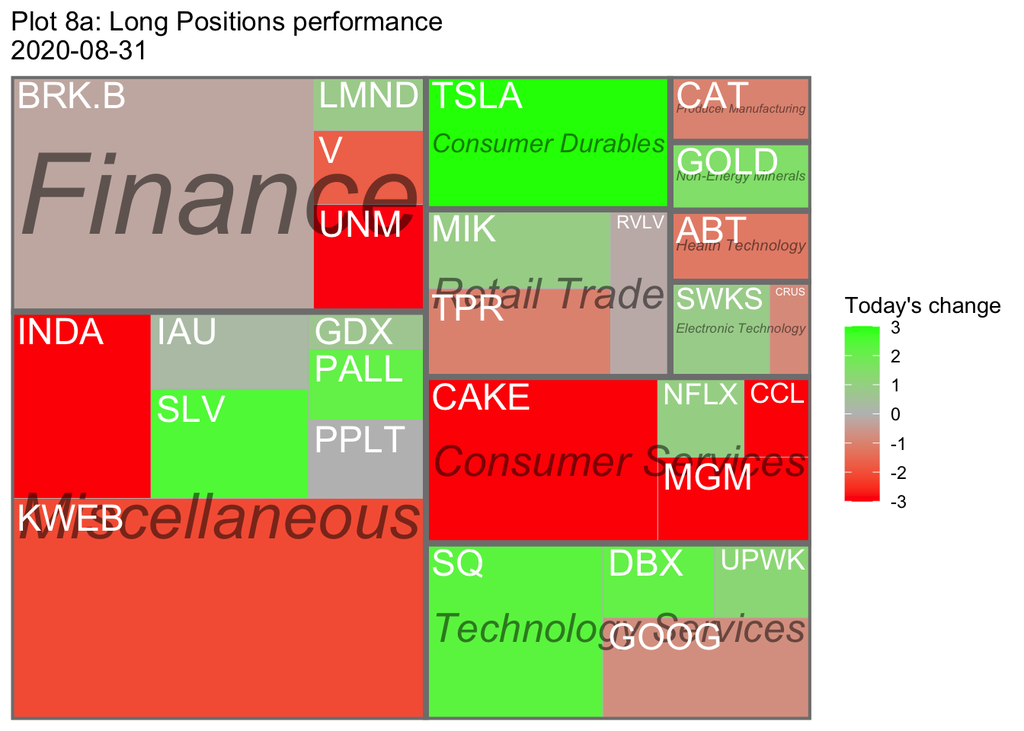

Short postions

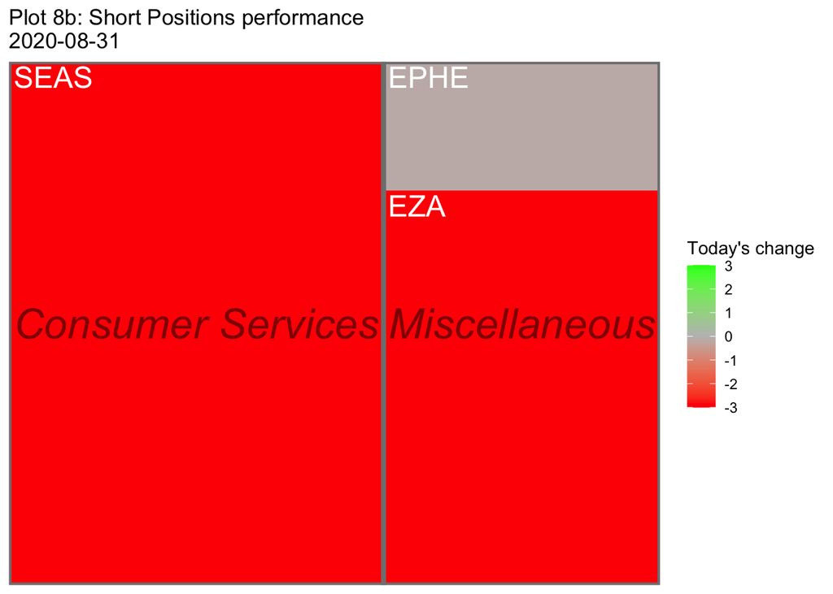

S&P 500 stocks colored by last day performance.

Outliers skew the colors, making the other stocks look pale. I restricted the colors to max of 3 and -3% change. Every stock having higher or lower than 3% change has the same color.

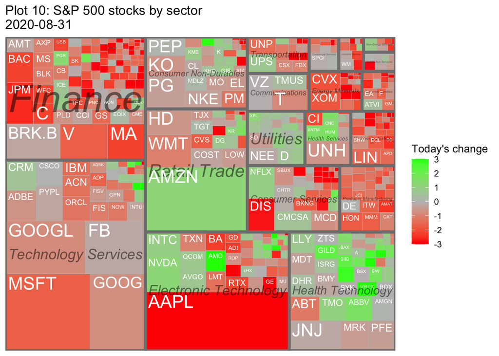

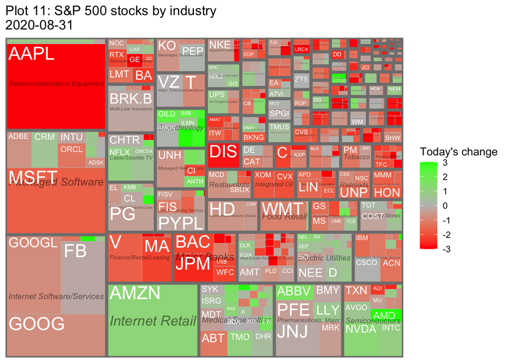